# Modeling / Regression

Updated: Tuesday, February 16, 2021 @ 10:47:38 AM

## Before We Begin…

These slides are not meant to be standalone information. You should take notes to flesh out the contents. I recommend that you create an R Markdown document where you can combine information and code from the slides and your own additional notes and explorations to make connections.

**Related Materials**

- Ch 9 of *Mathematical Statistics with Resampling and R, 2<sup>nd</sup> Ed.*
- Ch 5 of [*Modern Dive*](https://moderndive.com/5-regression.html)
- Ch 6 of [*Modern Dive*](https://moderndive.com/6-multiple-regression.html)
- DataCamp [Modeling with Data in the Tidyverse](https://learn.datacamp.com/courses/modeling-with-data-in-the-tidyverse)

## Modeling

### What is a model?

[figure not shown]

### What is a *mathematical* model?

## A General Model

General modeling framework: \(y\) is a function of one or more \(x\) variables, plus some amount of random error.

\[y = f(\overrightarrow{x}) + \epsilon\]

- y is the *outcome*, *response*, or *predicted* variable
- x is an *explanatory* or *predictor* variable (“signal”)
- \(\epsilon\) is the unsystematic error component (“noise”)

The function \(f(\overrightarrow{x})\) can assume a variety of forms, depending on the system and relationships we are trying to model. Finding the right model is often an iterative process. We often assume that \(\epsilon\) is a normally distributed random variable.

## Simple Linear Model

Our theoretical simple linear model has the following form, with \(f(x)\) being the familiar equation of a straight line.

\[y = f(x) + \epsilon = \beta_0 + \beta_1 x + \epsilon\]

We use data to estimate the \(\beta\) parameters. The observed value of the *ith* data point \(y_i\) in the sample can be expressed in terms of the fitted line and a residual (deviation from the line).

\[y_i = b_0 + b_1 x_i + e_i\]

The fitted (predicted) value \(\hat{y}_i\) is a point lying on the fitted line, obtained by plugging the value \(x_i\) into the fitted line.

\[\hat{y}_i = b_0 + b_1 x_i \rightarrow y_i = \hat{y}_i + e_i\]

[figure not shown]

image source: https://towardsdatascience.com/when-your-regression-models-errors-contain-two-peaks-13d835686ca

## The “Best Fit” Line

The residual for each data point is the difference between the observed value of y and the predicted value of y.

\[y_i - \hat{y}_i = (b_0 + b_1 x_i + e_i) - (b_0 + b_1 x_i) = e_i\]

In least squares modeling, the best-fit line has the properties:

- Passes through the point \((\bar{x}, \bar{y})\)
- Sum of the residuals \(\sum_{i=1}^{n} e_i\) is equal to zero
- Sum of the squared residuals \(\sum_{i=1}^{n} {e_i}^2\) is minimized

The sum of squared residuals (SSE) is an important quantity in regression analysis and is used for several purposes.

## Interpreting Slope and Intercept

Mathematically, the y-intercept \(\beta_0\) and its estimate \(b_0\) represent the value of \(\hat{y}\) when \(x\) = 0.

The intercept term may or may not have a useful interpretation in context, depending on whether \(x\) = 0 is meaningful.

The units of measure for the intercept are the same as the units of measure for the \(y\) variable.

Slope is a rate of change; how many units of measure does the \(\hat{y}\) value change when \(x\) changes by one unit.

Since slope is a rate (\(\Delta y\) / \(\Delta x\)), the units of measure for slope are (\(y\) units of measure / \(x\) units of measure).

## Are People Squares?

Roman architect [Vitruvius](https://www.ancient.eu/Vitruvius/) wrote that a person’s height is equal to their armspan. Leonardo da Vinci later illustrated this idea.

[figure not shown]

## Our Vitruvian Model

A general model, if we use height to explain / predict armspan…

\[armspan = \beta_0 + \beta_1 (height) + \epsilon\]

If Vitruvius is correct, what is the model’s slope and y-intercept?

\(armspan =\) _____ \(+\) _____ \((height) + \epsilon\)

What would the value of \(\epsilon\) be if all people were perfect squares?

Individual people are likely not perfect squares, but maybe they are squares *on average*, with some amount of random variation for each person. For example, the *average* armspan for everyone 5’9" tall is 5’9", but some people have longer/shorter armspans.

Or … maybe height and armspan have a different relationship?

## Anthropometric Data

The datafile anthropometric.csv contains measurements from some of Dr. Thomley’s previous stats students ([description](https://stat-jet-asu.github.io/Datasets/InstructorDescriptions/anthropometric.html)).

```r
glimpse(anthro)
```

```
Rows: 547
Columns: 9
$ gender   <fct> female, female, female, female, female, female, female, fema…
$ ideal    <dbl> 64, 64, 65, 63, 68, 64, NA, 65, 66, 63, 62, 60, 65, 68, 64, …
$ height   <dbl> 59.75, 59.75, 60.00, 60.00, 60.00, 60.00, 60.50, 60.50, 61.0…
$ armspan  <dbl> 58.5, 58.5, 61.0, 58.0, 62.0, 60.0, 60.0, 61.5, 63.0, 59.0, …
$ forearm  <dbl> 15.00, 15.00, 16.00, 15.00, 15.00, 15.00, 15.50, 15.00, 16.5…
$ hand     <dbl> 6.50, 6.50, 7.00, 6.25, 6.00, 6.00, 5.50, 7.00, 7.00, 6.00, …
$ leg      <dbl> 16.00, 16.00, 16.00, 16.25, 18.00, 16.00, 17.75, 16.50, 19.0…
$ foot     <dbl> 8.50, 8.50, 8.50, 9.50, 9.00, 8.00, 8.50, 8.50, 9.50, 8.75, …
$ semester <fct> F15, F15, F13, F15, S13, Sum13, S14, Sum14, F15, S13, S13, S…
```

## Take a Sample

The dataset is large, so let’s take a smaller sample to start with. The `sample_n` function comes from `dplyr`. Setting a seed value ensures we all have the same “random” sample.

```r
set.seed(1)
anthro_sample <- sample_n(anthro, 20)
head(anthro_sample)
```

```
  gender ideal height armspan forearm hand  leg foot semester
1 female 64.50  64.50    67.5   17.25 7.50 19.0  9.5    Sum15
2   male 78.00  74.25    78.0   21.50 8.00 17.5 13.0      S14
3   male 75.00  73.00    72.0   20.00 7.00 18.0  8.0      S13
4   male 72.25  68.50    69.0   18.00 7.25 17.0  9.5      S14
5   male 70.00  68.00    67.0   18.50 7.50 20.0 10.0      S13
6 female 66.00  66.00    65.0   16.50 7.00 20.0 10.0      S13
```

## EDA First!

Conduct exploratory data analyses on the x and y variables to investigate their shape, center, spread, and outliers.

[figure not shown]

## Scatterplot

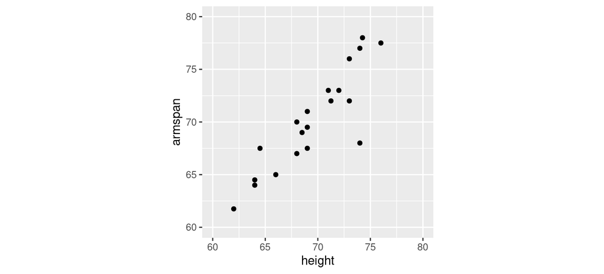

```r
# using coord_fixed because x and y have the same scale
ggplot(anthro_sample, aes(x = height, y = armspan)) +
  geom_point() +
  coord_fixed(xlim = c(60, 80), ylim = c(60, 80))
```

## Scatterplot with Fitted Line

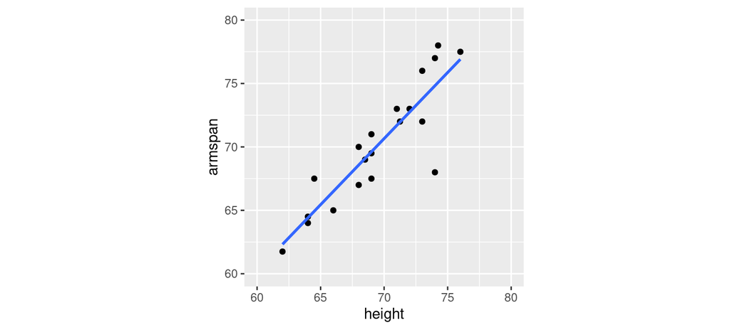

```r
ggplot(anthro_sample, aes(x = height, y = armspan)) +
  geom_point() +
  geom_smooth(method = "lm", se = FALSE) +
  coord_fixed(xlim = c(60, 80), ylim = c(60, 80))
```

## Visualize the Residuals

The dashed lines on the scatterplot represent \(\bar{x}\) and \(\bar{y}\).

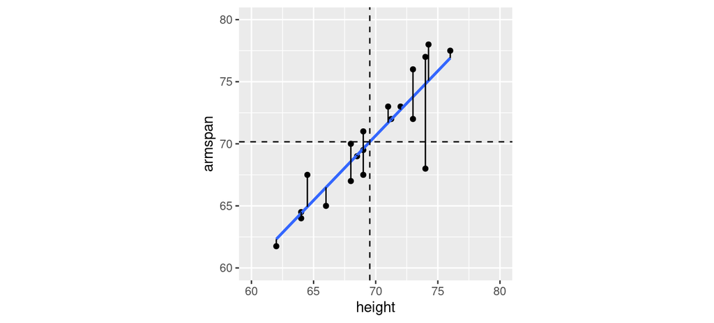

```
 [1] -0.571  0.095 -0.405  2.574 -1.489 -1.573  1.427 -0.094 -2.115 -0.115
[11]  1.385  1.300  0.040  0.258 -1.784  2.216  2.174 -6.826  2.914  0.590
```

## Scatterplot with Fitted & Plotted Lines

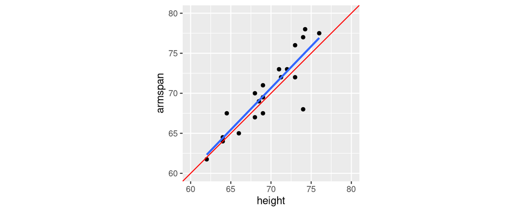

```r
ggplot(anthro_sample, aes(x = height, y = armspan)) +
  geom_point() +
  geom_smooth(method = "lm", se = FALSE) +               # fitted line
  geom_abline(intercept = 0, slope = 1, color = "red") + # theoretical
  coord_fixed(xlim = c(60, 80), ylim = c(60, 80))
```

## Different Samples, Varying Estimates

```r
# there are more efficient ways to do this, notice the pattern

size_n <- 20

sample01 <- sample_n(anthro, size_n) %>% mutate(samplenum = "S01")
sample02 <- sample_n(anthro, size_n) %>% mutate(samplenum = "S02")
sample03 <- sample_n(anthro, size_n) %>% mutate(samplenum = "S03")
sample04 <- sample_n(anthro, size_n) %>% mutate(samplenum = "S04")
sample05 <- sample_n(anthro, size_n) %>% mutate(samplenum = "S05")
sample06 <- sample_n(anthro, size_n) %>% mutate(samplenum = "S06")
sample07 <- sample_n(anthro, size_n) %>% mutate(samplenum = "S07")
sample08 <- sample_n(anthro, size_n) %>% mutate(samplenum = "S08")

eightsamps <- rbind(sample01, sample02, sample03, sample04,
                    sample05, sample06, sample07, sample08)
```

## Plotting All the Estimated Lines

Each sample yields a different estimate, but similar in slope.

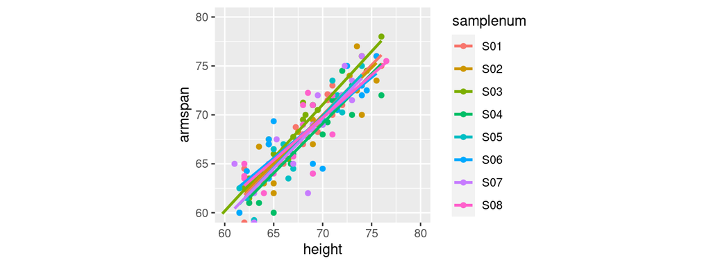

```r
ggplot(eightsamps, aes(x = height, y = armspan, color = samplenum)) +
  geom_point() +
  geom_smooth(method = "lm", se = FALSE) +
  coord_fixed(xlim = c(60, 80), ylim = c(60, 80))
```

## Fitting the Linear Model

The `lm()` function fits the least squares model and computes many related statistics. Far more information is computed and stored than the output that is displayed by default.

```r
square_model <- lm(armspan ~ height, data = anthro_sample)

# default output is the regression coefficients b0 and b1
square_model
```

```
Call:
lm(formula = armspan ~ height, data = anthro_sample)

Coefficients:
(Intercept)       height
     -2.286        1.042
```

```r
summary(square_model) # summary() gives us more output
```

```
Call:
lm(formula = armspan ~ height, data = anthro_sample)

Residuals:
    Min      1Q  Median      3Q     Max
-6.8257 -0.8007  0.0674  1.3951  2.9138

Coefficients:
            Estimate Std. Error t value Pr(>|t|)
(Intercept)   -2.286      8.979  -0.255    0.802
height         1.042      0.129   8.081 2.12e-07 ***
---
Signif. codes:  0 '***' 0.001 '**' 0.01 '*' 0.05 '.' 0.1 ' ' 1

Residual standard error: 2.239 on 18 degrees of freedom
Multiple R-squared:  0.7839,    Adjusted R-squared:  0.7719
F-statistic:  65.3 on 1 and 18 DF,  p-value: 2.123e-07
```

The `lm()` function produces a `list` as output. We can access the components using the `$` notation.

```r
str(square_model)
```

```
List of 12
 $ coefficients : Named num [1:2] -2.29 1.04
  ..- attr(*, "names")= chr [1:2] "(Intercept)" "height"
 $ residuals    : Named num [1:20] 2.5738 2.9138 -1.7836 -0.0944 -1.5734 ...
  ..- attr(*, "names")= chr [1:20] "1" "2" "3" "4" ...
 $ effects      : Named num [1:20] -313.776 -18.097 -2.72 -0.553 -1.979 ...
  ..- attr(*, "names")= chr [1:20] "(Intercept)" "height" "" "" ...
 $ rank         : int 2
 $ fitted.values: Named num [1:20] 64.9 75.1 73.8 69.1 68.6 ...
  ..- attr(*, "names")= chr [1:20] "1" "2" "3" "4" ...
 $ assign       : int [1:2] 0 1
 $ qr           :List of 5
  ..$ qr   : num [1:20, 1:2] -4.472 0.224 0.224 0.224 0.224 ...
  .. ..- attr(*, "dimnames")=List of 2
  .. .. ..$ : chr [1:20] "1" "2" "3" "4" ...
  .. .. ..$ : chr [1:2] "(Intercept)" "height"
  .. ..- attr(*, "assign")= int [1:2] 0 1
  ..$ qraux: num [1:2] 1.22 1.32
  ..$ pivot: int [1:2] 1 2
  ..$ tol  : num 1e-07
  ..$ rank : int 2
  ..- attr(*, "class")= chr "qr"
 $ df.residual  : int 18
 $ xlevels      : Named list()
 $ call         : language lm(formula = armspan ~ height, data = anthro_sample)
 $ terms        :Classes 'terms', 'formula'  language armspan ~ height
  .. ..- attr(*, "variables")= language list(armspan, height)
  .. ..- attr(*, "factors")= int [1:2, 1] 0 1
  .. .. ..- attr(*, "dimnames")=List of 2
  .. .. .. ..$ : chr [1:2] "armspan" "height"
  .. .. .. ..$ : chr "height"
  .. ..- attr(*, "term.labels")= chr "height"
  .. ..- attr(*, "order")= int 1
  .. ..- attr(*, "intercept")= int 1
  .. ..- attr(*, "response")= int 1
  .. ..- attr(*, ".Environment")=<environment: R_GlobalEnv>
  .. ..- attr(*, "predvars")= language list(armspan, height)
  .. ..- attr(*, "dataClasses")= Named chr [1:2] "numeric" "numeric"
  .. .. ..- attr(*, "names")= chr [1:2] "armspan" "height"
 $ model        :'data.frame':  20 obs. of  2 variables:
  ..$ armspan: num [1:20] 67.5 78 72 69 67 65 67.5 70 77 69.5 ...
  ..$ height : num [1:20] 64.5 74.2 73 68.5 68 ...
  ..- attr(*, "terms")=Classes 'terms', 'formula'  language armspan ~ height
  .. .. ..- attr(*, "variables")= language list(armspan, height)
  .. .. ..- attr(*, "factors")= int [1:2, 1] 0 1
  .. .. .. ..- attr(*, "dimnames")=List of 2
  .. .. .. .. ..$ : chr [1:2] "armspan" "height"
  .. .. .. .. ..$ : chr "height"
  .. .. ..- attr(*, "term.labels")= chr "height"
  .. .. ..- attr(*, "order")= int 1
  .. .. ..- attr(*, "intercept")= int 1
  .. .. ..- attr(*, "response")= int 1
  .. .. ..- attr(*, ".Environment")=<environment: R_GlobalEnv>
  .. .. ..- attr(*, "predvars")= language list(armspan, height)
  .. .. ..- attr(*, "dataClasses")= Named chr [1:2] "numeric" "numeric"
  .. .. .. ..- attr(*, "names")= chr [1:2] "armspan" "height"
 - attr(*, "class")= chr "lm"
```

## Accessing Output Components

```r
square_model$coefficients
```

```
(Intercept)      height
  -2.285668    1.042045
```

```r
square_model$residuals
```

```
          1           2           3           4           5           6
 2.57377533  2.91383812 -1.78360583 -0.09440404 -1.57338162 -1.48929193
          7           8           9          10          11          12
-2.11542646  1.42661838  2.17434933 -0.11542646 -0.57111256  0.09479775
         13          14          15          16          17          18
 2.21639417  1.30048386  1.38457354  0.59025965  0.25843902 -0.40520225
         19          20
 0.03997265 -6.82565067
```

## Formatting Results—Coefficients

The package `moderndive` contains some “wrapper” functions to help easily access and format regression output for information and additional analysis.

```r
square_model_table <- get_regression_table(square_model)

square_model_table
```

```
# A tibble: 2 x 7
  term      estimate std_error statistic p_value lower_ci upper_ci
  <chr>        <dbl>     <dbl>     <dbl>   <dbl>    <dbl>    <dbl>
1 intercept    -2.29     8.98     -0.255   0.802  -21.2      16.6
2 height        1.04     0.129     8.08    0        0.771     1.31
```

This output is a `tibble`. Why is this potentially useful to us?

## Accessing Results—Coefficients

We can also print the results in a formatted Markdown version. It looks somewhat different in reports versus slides.

```r
get_regression_table(square_model, digits = 2, print = TRUE)
```

| term | estimate | std_error | statistic | p_value | lower_ci | upper_ci |
| --- | --- | --- | --- | --- | --- | --- |
| intercept | -2.29 | 8.98 | -0.25 | 0.8 | -21.15 | 16.58 |
| height | 1.04 | 0.13 | 8.08 | 0.0 | 0.77 | 1.31 |

The CIs help estimate the true values of the slope and intercept for the population versus just our data. (*We will dive more deeply into CIs later in the course.*)

## Accessing Results—Fits and Residuals

```r
square_model_points <- get_regression_points(square_model)

head(square_model_points)
```

```
# A tibble: 6 x 5
     ID armspan height armspan_hat residual
  <int>   <dbl>  <dbl>       <dbl>    <dbl>
1     1    67.5   64.5        64.9    2.57
2     2    78     74.2        75.1    2.91
3     3    72     73          73.8   -1.78
4     4    69     68.5        69.1   -0.094
5     5    67     68          68.6   -1.57
6     6    65     66          66.5   -1.49
```

What are `armspan_hat` and `residual`?

There is also a `digits` and `print` option for this function.

## Assessing Results—R<sup>2</sup>

R<sup>2</sup> is the proportion of variation in the \(y\) variable explained by the model \(f(x)\). It is also known as *coefficient of determination*.

\[R^2 = 1 - \frac{var(residuals)}{var(y)} = \frac{var(y)-var(residuals)}{var(y)}\]

\[0 \le R^2 \le 1\]

For a deterministic relationship where \(x\) is a perfect predictor of \(y\), R<sup>2</sup> = 1 (all variation explained).

If \(x\) and \(y\) have no relationship with respect to the fitted model, R<sup>2</sup> = 0 (no variation explained).

## Model Fit?

R<sup>2</sup> is often used to assess model fit and to compare potential models for the same data. In general, larger values indicate a better fit (*but be cautious, there are other assumptions*).

[figure not shown]

## R<sup>2</sup> for Our Vitruvian Model

```r
square_model_points %>%
  summarise(R_squared = 1 - var(residual) / var(armspan))
```

```
# A tibble: 1 x 1
  R_squared
      <dbl>
1     0.784
```

```r
summary(square_model)$r.squared
```

```
[1] 0.7839168
```

About 78% of the variability in people’s armspans is explained by our model using height.

## Model Summaries

There are additional summaries that help us interpret and make predictions using the fitted linear model.

```r
get_regression_summaries(square_model, digits = 2, print = TRUE)
```

| r_squared | adj_r_squared | mse | rmse | sigma | statistic | p_value | df | nobs |
| --- | --- | --- | --- | --- | --- | --- | --- | --- |
| 0.78 | 0.77 | 4.51381 | 2.124573 | 2.24 | 65.3 | 0 | 1 | 20 |

RMSE is the standard deviation of the model residuals, with n as the denominator and \(\Sigma (y_i - \hat{y}_i)^2\) as the numerator.

Sigma is an estimate of the standard deviation of the population errors (\(\epsilon\)), with denominator n - 2 (if there is one predictor).

## Parallel Slopes Model

Suppose we have a situation in which there are subgroups in our data whose models are parallel: they have the same slope but different intercepts.

\[y = f(x_1, x_2) + \epsilon = \beta_0 + \beta_1 x_1 + \beta_2 x_2 + \epsilon\]

- \(x_1\) = quantitative predictor variable
- \(x_2\) = categorical grouping variable

If \(x_2\) has two categories, represented by 0 and 1…

model_0: \(\beta_0 + \beta_1 x_1 + \beta_2 (0) = \beta_0 + \beta_1 x_1\)

model_1: \(\beta_0 + \beta_1 x_1 + \beta_2 (1) = (\beta_0 + \beta_2) + \beta_1 x_1\)

## Parallel Slopes Model

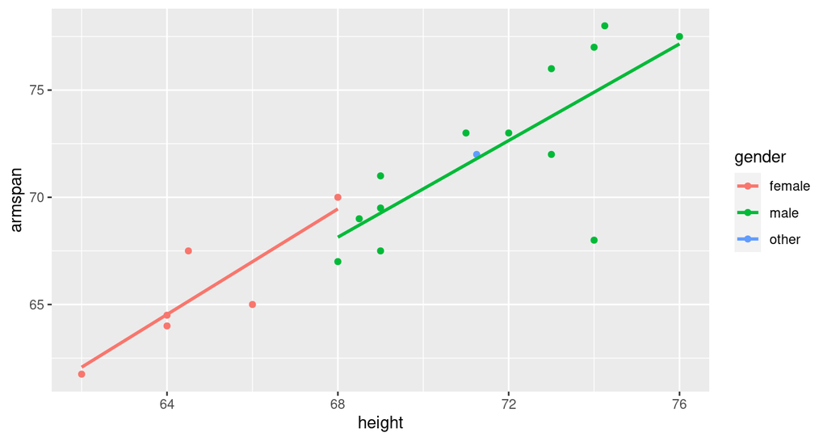

```r
ggplot(anthro_sample, aes(x = height, y = armspan, color = gender)) +
  geom_point() + geom_smooth(method = "lm", se = FALSE)
```

```r
square_model_pll <- lm(armspan ~ height + gender, data = anthro_sample)

get_regression_table(square_model_pll, print = TRUE)
```

| term | estimate | std_error | statistic | p_value | lower_ci | upper_ci |
| --- | --- | --- | --- | --- | --- | --- |
| intercept | -8.833 | 14.813 | -0.596 | 0.559 | -40.234 | 22.568 |
| height | 1.147 | 0.228 | 5.026 | 0.000 | 0.663 | 1.631 |
| gendermale | -1.121 | 1.947 | -0.576 | 0.573 | -5.247 | 3.005 |
| genderother | -0.916 | 2.941 | -0.311 | 0.759 | -7.151 | 5.319 |

What are the equations of the two models?

model_F:

model_M:

```r
summary(square_model_pll)
```

```
Call:
lm(formula = armspan ~ height + gender, data = anthro_sample)

Residuals:
    Min      1Q  Median      3Q     Max
-6.9504 -0.7149  0.2707  1.5654  2.7628

Coefficients:
            Estimate Std. Error t value Pr(>|t|)
(Intercept)  -8.8331    14.8126  -0.596 0.559303
height        1.1474     0.2283   5.026 0.000124 ***
gendermale   -1.1210     1.9465  -0.576 0.572696
genderother  -0.9162     2.9412  -0.311 0.759449
---
Signif. codes:  0 '***' 0.001 '**' 0.01 '*' 0.05 '.' 0.1 ' ' 1

Residual standard error: 2.351 on 16 degrees of freedom
Multiple R-squared:  0.7883,    Adjusted R-squared:  0.7486
F-statistic: 19.86 on 3 and 16 DF,  p-value: 1.213e-05
```